# Tipos de gráficos

# Graficos

Aqui aprenderemos a generar leyendas y graficar boxplots

# Boxplots

Los boxplots son de los graficos mas utilizados para condensar un gran numero de informacion combinando una variable discreta (x) y una variable continua (y)

```r
theme_set(theme_bw())

ggplot(CO2, aes(x = Type, y = uptake)) +
  geom_boxplot(fill = "red",
               color = "green") # A partir de las variedades
```

```r
ggplot(CO2, aes(x = Type, y = uptake, fill = Treatment)) +
  geom_boxplot() # A partir de tratamientos

ggplot(CO2, aes(x = Type, y = uptake, fill = Type)) +
  geom_boxplot()

ggplot(CO2, aes(x = Type, y = uptake, fill = Plant)) +
  geom_boxplot()
```

Al agregar esta otra variable el boxplot automaticamente detecta que tenemos dos variables independientes las cuales se deben de utilizar separando grupos. ggplot tiene colores automáticos

## Leyendas

Pero ahora si, veamos como modificar las leyendas

```r
# Si la leyenda nos estorba

ggplot(CO2, aes(x = Type, y = uptake, fill = Treatment)) +
  geom_boxplot() +
  theme(legend.position = "none") # Para quitar la leyenda

# si queremos que no tenga titulo la leyenda

ggplot(CO2, aes(x = Type, y = uptake, fill = Treatment)) +
  geom_boxplot() +
  theme(legend.title = element_blank()) # significa vacio

# Otra opcion u otra forma

ggplot(CO2, aes(x = Type, y = uptake, fill = Treatment)) +
  geom_boxplot() +
  scale_fill_discrete(name = NULL) # no le estoy poniendo nombre
```

Si bien las leyendas del van del lado derecho de nuestro grafico, podemos cambiarla de lugar

```r
ggplot(CO2, aes(x = Type, y = uptake, fill = Treatment)) +
  geom_boxplot() +
  theme(legend.position = "top") # Poner la leyenda arriba
```

Y como nuestras otras variables tambien podemos modificar el formato del texto

```r
ggplot(CO2, aes(x = Type, y = uptake, fill = Treatment)) +
  geom_boxplot() +
  theme(legend.title = element_text(color = "chocolate",
        size = 10,
        face = "bold")) +
  ggtitle("Dióxido de Carbono") +
  theme(plot.title = element_text(hjust = .5, size = 15, face = "italic"))
   # Titulo
```

```r
# Cambiar el orden de los datos

CO2$Treatment <- factor(CO2$Treatment,
                        levels = c("chilled", "nonchilled"),
                        ordered = TRUE) # Aqui ordenamos la tabla para que aparezca primero chilled y luego nonchilled

ggplot(CO2, aes(x = Type, y = uptake, fill = Treatment)) +
  geom_boxplot() # Aqui la grafica ya presento primero el tratamiento chilled en la leyenda

# Cambiar el nombre de los datos

ggplot(CO2, aes(x = Type, y = uptake, fill = Treatment)) +
  geom_boxplot() +
  scale_fill_discrete(name = "Tratamientos",
                      labels = c("Frio", "Temperado")) +
  xlab("Tipo de Planta") + ylab(bquote("Absorción de CO"[2])) +
  ggtitle ("Figura 1") +
  theme(plot.title = element_text(hjust = .5, face = "italic"))
```

Mas opciones para cambiar las leyendas… [Tutorial de modificaciones de leyendas y elementos de un grafico](https://www.cedricscherer.com/2019/08/05/a-ggplot2-tutorial-for-beautiful-plotting-in-r/#legends)

### Ejercicio

Usando los datos de Comp_soils quiero que grafiquen un boxplot de una variable diferente cada quien en el que comparen tipo de suelo por temperatura. Ademas deben de modificar por lo menos una vez los siguiente elementos:

1. Modificacion a la leyenda (que no sea quitarla!)
2. Etiquetas de los ejes
3. Modificacion de la escala de los ejes
4. Un titulo con por lo menos una modificacion en formato

```r
ggplot(comp_soils, aes(x = Temperature, y = NH3.ugL, fill = Soil)) +
  geom_boxplot()

ggplot(comp_soils, aes(x = Temperature, y = NH3.ugL, fill = Soil)) +
  geom_boxplot() +
  scale_fill_discrete(name = "Tipo de suelo",
                      labels = c("Capa activa", "Permafrost")) +
  xlab("Temperatura") + ylab(bquote("Contenido de NH"[3](ug/L))) +
  ylim(c(0,2000)) +
  ggtitle("Contenido de NH3") +
  theme(plot.title = element_text(face = "italic", hjust = .5, size = 15)) +
  theme(axis.title.x = element_text(size = 9), axis.title.y = element_text(size = 9))
```

# Modificando colores en boxplots

aqui el orden si importa, entonces hay que hacer lo siguiente:

```r
ggplot(CO2, aes(x = Type, y = uptake, fill = Treatment)) +
  geom_boxplot() +
  scale_fill_manual(name = "Treatment",
                    values = c("green", "red")) # Tiene que ser cada color para cada variable, el fill arriba debe de mantenerse en el fill de scale_fill_manual

# Diferencia entre fill y color

ggplot(CO2, aes(x = Type, y = uptake, color = Treatment)) +
  geom_boxplot() +
  scale_color_manual(name = "Treatment",
                    values = c("green", "red")) # El color arriba debe de ser igual abajo en scale_color_manual.

# Cambiando o combinando uno y otro

ggplot(CO2, aes(x = Type, y = uptake, fill = Treatment)) +
  geom_boxplot(col = "yellow") + # Lo cambia en amba
  scale_fill_manual(name = "Treatment",
                    values = c("green", "red"))

# Cambiar ambos por variables

ggplot(CO2, aes(x = Type, y = uptake, col = Treatment, fill = Treatment)) +
  geom_boxplot() +
  scale_color_manual(name = "Treatment",
                    values = c("purple", "red"))+
  scale_fill_manual(name = "Treatment",
                    values = c("yellow", "blue"))
```

# Otras cosas que se pueden modificar en los boxplots:

- outlier.colour, outlier.shap, outlier.size
- notch
- lwd, alpha (transparencia)
- puntos de media
- boxdots

```r
# Outliers

ggplot(CO2, aes(x = Type, y = uptake, fill = Treatment)) +
  geom_boxplot(outlier.colour = "black", outlier.size = 2, outlier.shape = 16) +
   scale_fill_manual(name = "Treatment",
                    values = c("green", "red"))

# Notch

ggplot(CO2, aes(x = Type, y = uptake, fill = Treatment)) +
  geom_boxplot(notch = TRUE) +
  scale_fill_manual(name = "Treatment",
                    values = c("green", "red"))

# lwd, alpha

ggplot(CO2, aes(x = Type, y = uptake, fill = Treatment)) +
  geom_boxplot(lwd = 0.01, alpha = 0.2) +
  scale_fill_manual(name = "Treatment",
                    values = c("green", "red"))

# mean dots

ggplot(CO2, aes(x = Type, y = uptake, fill = Treatment)) +
  geom_boxplot(alpha = 0.4) +
  scale_fill_manual(name = "Treatment",
                    values = c("green", "red"))+
  stat_summary(fun.y = mean, geom = "point", shape = 12, size = 1,
               position = position_dodge(1))

# Boxdots

ggplot(CO2, aes(x = Type, y = uptake, fill = Treatment)) +
  geom_boxplot(alpha = 0.4) +
  scale_fill_manual(name = "Treatment",
                    values = c("green", "red"))+
  geom_dotplot(binaxis = "y", stackdir = "center", dotsize = 1,
               position = position_dodge(1))
```

## Ejercicio

Al boxplot que hicimos en el ejercicio anterior modificar lo siguiente:

1. Colores dentro del grafico (color y/o fill)
2. Como se van a ver los outliers.

```r
ggplot(comp_soils, aes(x = Soil, y = NH3.ugL, fill = Temperature)) +
  geom_boxplot(alpha = 0.5, outlier.fill = "black", outlier.shape = 23) +
  scale_fill_manual(name = "Tipo de suelo",
                      labels = c("Capa activa", "Permafrost"),
                    values = c("red", "blue")) +
  xlab("Temperatura") +
  ylab(bquote("Contenido de NH"[3](ug/L))) +
  ylim(c(0,2000)) +
  ggtitle("Contenido de NH3") +
  theme(plot.title = element_text(face = "italic", hjust = .5, size = 10))
```

## Continuando con los graficos de puntos

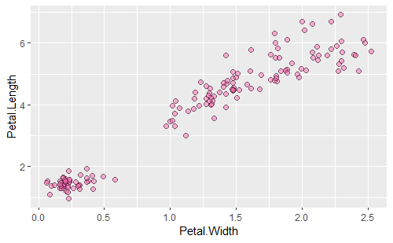

# Añadiendo mas informacion a nuestro gráfico

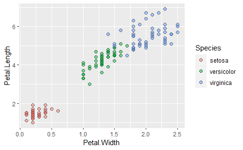

# Mini ejercicio

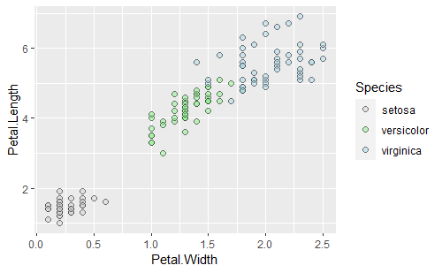

# Añadiendo correlaciójn

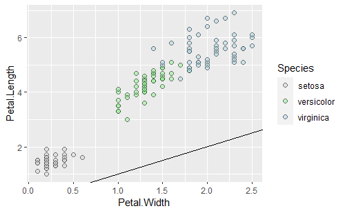

*Pero antes necesitamos añadir intercepto y pendiente*

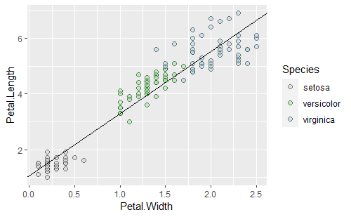

# O podemos usar un atajo con geom_smooth

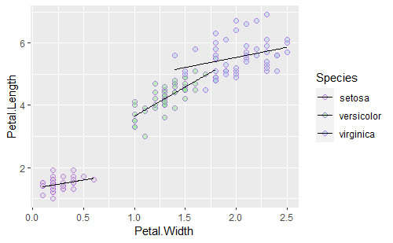

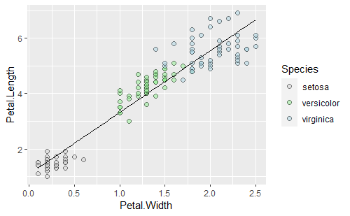

### Y la ecuación

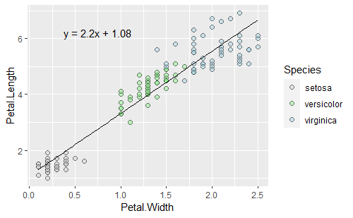

La funcion de annotate sirve para agregar cualquier tipo de texto a lo largo del grafico.

Sin embargo existen otro tipo de funciones de ggplot para agregar texto dentro del grafico:

geom_text agrega el texto al grafico mientras que geom_label lo pone en un rectangulo facilitano su lectura.

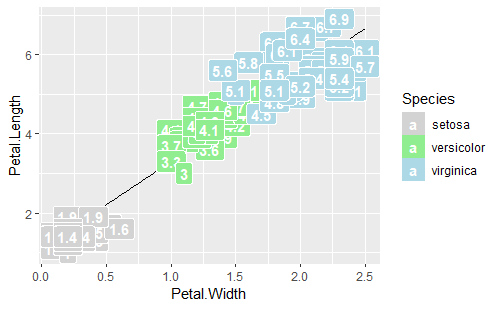

## Ejercicio

Hagan dos graficos con correlacion, uo para CO2 con minutos y otro metano con minuto. Ambos con linea de correlacion y ecuacion. Usar patchwork. Usar diferentes colores y formas de puntos.

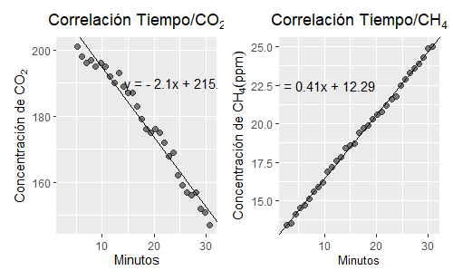

# Graficos de barras

En ggplot hay dos tipos de graficos de barras: geom_bar se describe su uso como para graficar cuentas de una sola variable discreta mientras que geom_col usa una variable discreta y una continua. Por ejemplo geom_bar podria usarse para contar el numero de casos en un grupo (numero de ratones encontrados por especie por ejemplo). En cambio geom_col usa valores dentro de los datos para representar la altura de la barra. Tambien existe geom_histogram pero ese funciona igual a un histograma normal por lo que sus usos son mas limitados.

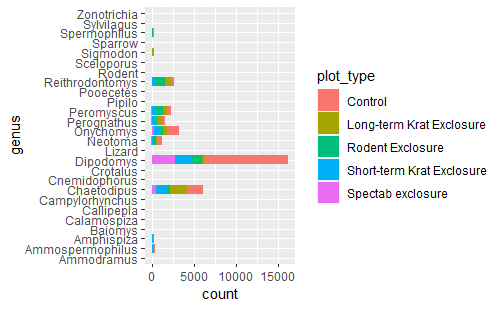

# Mini ejercicio

Agregar color diferente a las columnas pretederminadas

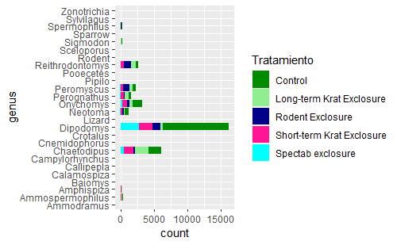

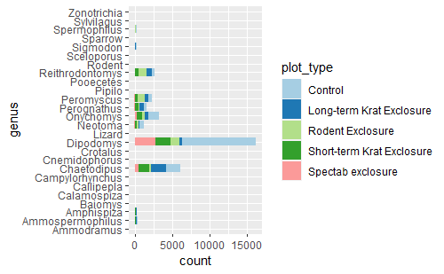

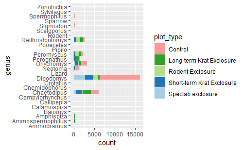

## Mejorar la visibilidad

Como hay muchas diferencias entre las abyundacias, es dificl ver las que tienen muy pocas, para esto podemos hacer cortes o breaks en los ejes.

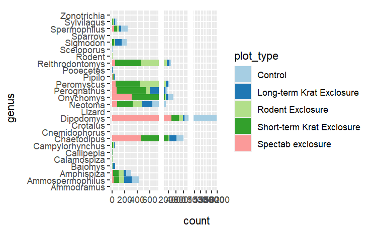

# Esto es para los valores medios

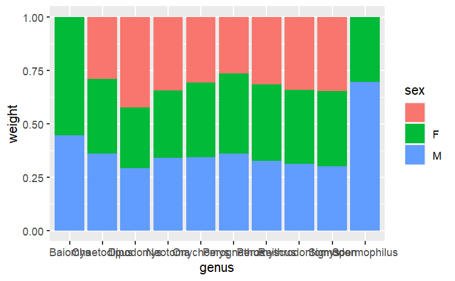

# Tambien se puede utilizar con geom_col

# Primero hay que realizar una tabla de cero con tdyverse

```r
Pesos <- roedores %>%
  group_by(genus, sex) %>%
  summarize(weight = mean(weight, na.rm = TRUE))
```

# Agrupación por grupos jeje